# HW 2 Exploration

Author

Ian Morris

Published

February 4, 2025

## Data Import

```r
# Read in three excel files from MARINe biodiversity data
point_contact_raw <- read_excel(here('data', 'MARINe_biodiversity_data',
                                     'cbs_data_CA_2023.xlsx'), sheet = 'point_contact_summary_data')
quadrat_raw <- read_excel(here('data', 'MARINe_biodiversity_data',
                               'cbs_data_CA_2023.xlsx'), sheet = 'quadrat_summary_data')
swath_raw <- read_excel(here('data', 'MARINe_biodiversity_data',
                             'cbs_data_CA_2023.xlsx'), sheet = 'swath_summary_data')

# Read in Dangermond preserve shape file
dangermond <- read_sf(here('data', 'dangermond_shapefile', 'jldp_boundary.shp'))

# Read in California state boundary
california <- spData::us_states %>%
  filter(NAME == "California")
```

## Data Cleaning

Lots of cleaning based on our capston project

```r
# Clean point_contact dataset
point_contact_clean <- point_contact_raw %>%
  # Remove non-matching columns
  select(!c('number_of_transect_locations', 'percent_cover')) %>%
  # Rename num of hits to total count
  rename(total_count = number_of_hits) %>%
  # Create new data collection source column
  mutate(collection_source = "point contact") %>%
  # Filter to mainland only
  filter(island == "Mainland") %>%
  # Remove certain species lumps
  filter(!species_lump %in% c("Rock", "Sand", "Tar", "Blue Green Algae", "Red Crust", "Diatom", "Ceramiales"))

# Clean quadrat dataset
quadrat_clean <- quadrat_raw %>%
  # Remove non-matching columns
  select(!c('number_of_quadrats_sampled', 'total_area_sampled_m2', 'density_per_m2')) %>%
  # Create new data collection source column
  mutate(collection_source = "quadrat") %>%
  # Filter to mainland only
  filter(island == "Mainland") %>%
  # Remove certain species lumps
  filter(!species_lump %in% c("Rock", "Sand", "Tar", "Blue Green Algae", "Red Crust", "Diatom", "Ceramiales"))

# Clean swath dataset
swath_clean <- swath_raw %>%
  # Remove non-matching columns
  select(!c('number_of_transects_sampled', 'est_swath_area_searched_m2',  'density_per_m2')) %>%
  # Create new data collection source column
  mutate(collection_source = "swath") %>%
  # Filter to mainland only
  filter(island == "Mainland") %>%
  # Remove certain species lumps
  filter(!species_lump %in% c("Rock", "Sand", "Tar", "Blue Green Algae", "Red Crust", "Diatom", "Ceramiales"))
```

#### Merge datasets

Merge data sets for easy calculations

```r
# Merge the 3 dataset together
biodiv_merge <- bind_rows(point_contact_clean, quadrat_clean, swath_clean)
```

```r
# Group by site and species (no year)
biodiv_total <- biodiv_merge %>%
  group_by(marine_site_name, latitude, longitude, species_lump, year) %>%
  summarise(num_count = sum(total_count))
```

```r
# Create column to indicate presence/absence
biodiv_total <- biodiv_total %>%
  mutate(presence = ifelse(num_count >= 1, 1, 0))
```

#### California Data

```r
# Convert to WGS84 to lat long
california <- st_transform(california, crs = 4326)
```

#### Convert biodiv data to sf object

```r
biodiv_geo <- biodiv_total %>%
  filter(presence == 1) %>%
  st_as_sf(coords = c("longitude", "latitude"), crs = st_crs(california), remove = FALSE)

# Check that the crs matches
if(st_crs(california) == st_crs(biodiv_geo)) {
  print("The coordinate reference systems match")
} else {
  print("The coordinate reference systems do NOT match. Transformation of CRS is recommended.")
}
```

```
[1] "The coordinate reference systems match"
```

```r
total_count <- biodiv_geo %>%
  group_by(species_lump) %>%
  summarise(
    total_count = sum(num_count)
  ) %>%
  arrange(desc(total_count))
```

```r
top_ten <- total_count %>%
  filter(!grepl("spp", species_lump)) %>%
  slice_max(order_by = total_count, n = 5) %>%
  arrange(total_count)
```

```r
top_ten_geo <- biodiv_geo %>%
  filter(species_lump  %in% top_ten$species_lump)
```

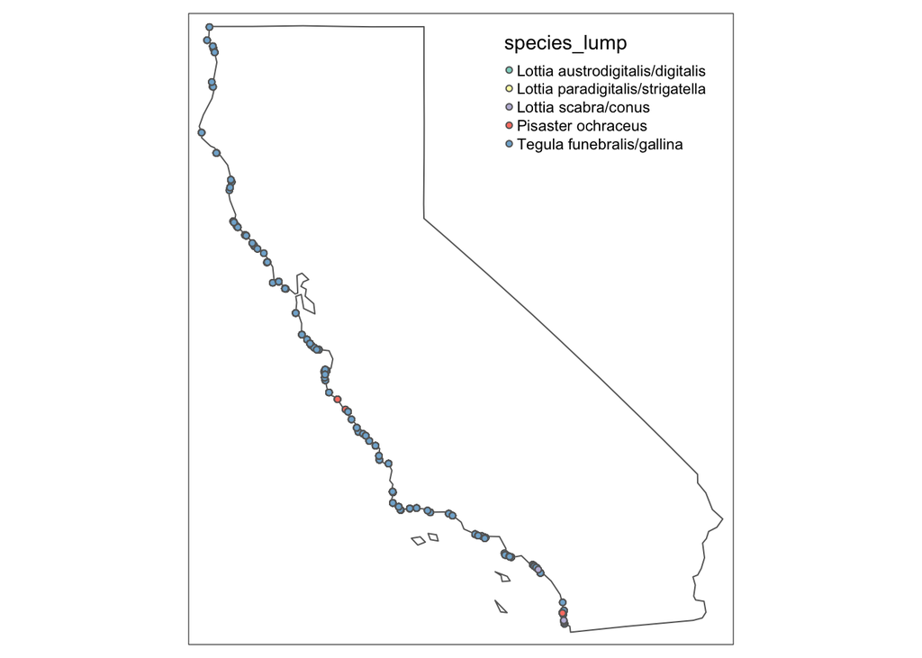

```r
tm_shape(california) +
  tm_borders() +
tm_shape(top_ten_geo) +
  tm_symbols(col = "species_lump", size = .1)
```

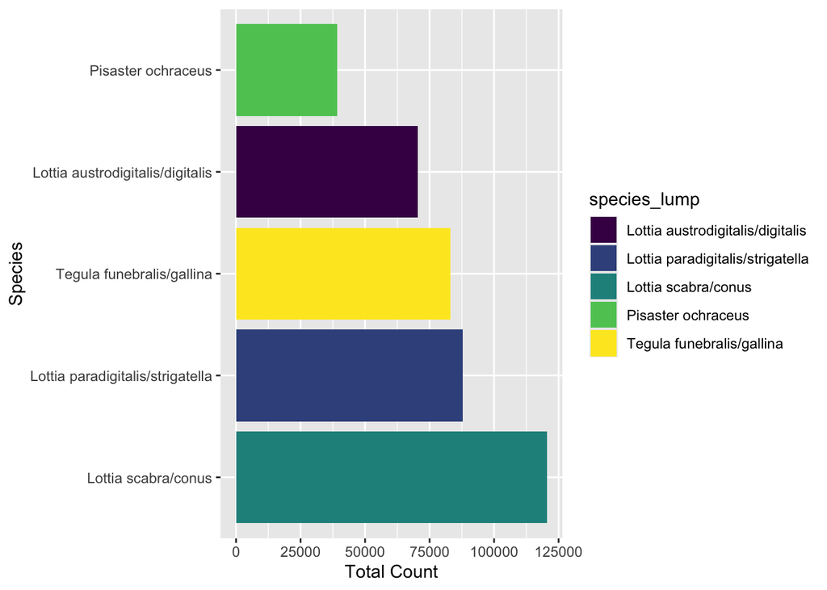

```r
top_ten %>%
  ggplot(aes(x=fct_infreq(species_lump, total_count),
           y = total_count, fill = species_lump)) +
  geom_col() +
  coord_flip() +
  scale_fill_viridis_d() +
  labs(y = "Total Count", x = "Species")
```

## Unique Species by Year

```r
species_freq <- biodiv_geo %>%
  group_by(year) %>%
  summarise(
    total_species = n_distinct(species_lump)
  )
```

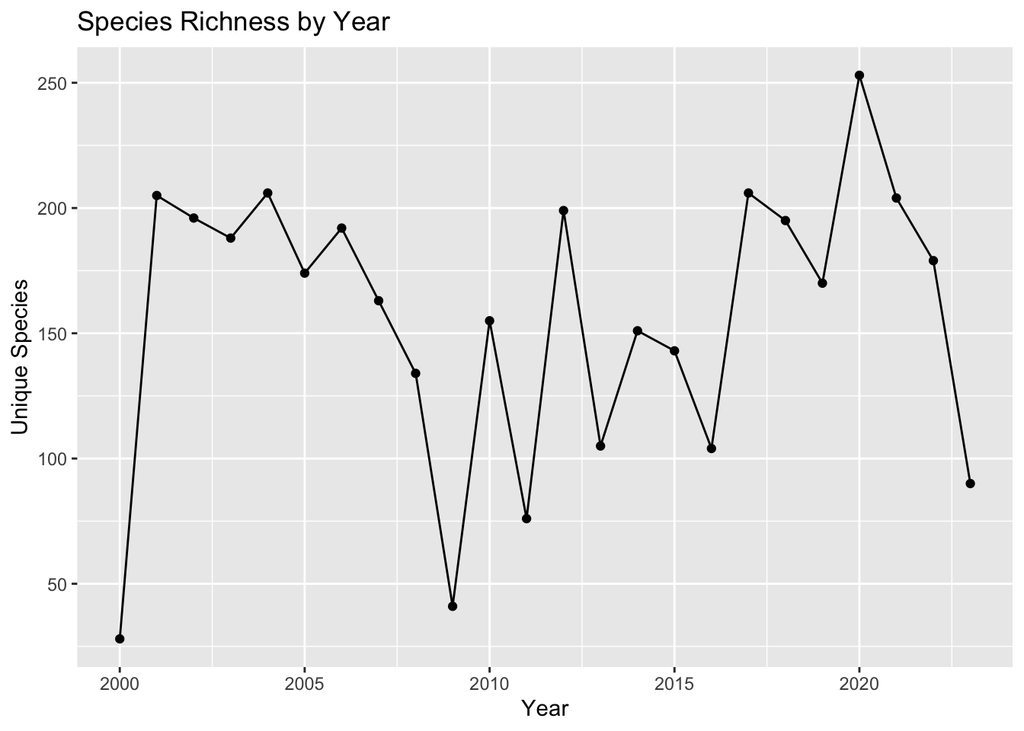

```r
ggplot(species_freq, aes(x = year, y = total_species)) +
  geom_line() +
  geom_point() +
  labs(
    title = "Species Richness by Year",
    x = "Year",
    y = "Unique Species"
  )
```

## Additional Questions

1. What have you learned about your data? Have any potentially interesting patterns emerged?

I have learned that there is a lot of species that are not as easily identified that make up the majority of observations. That is why I filtered out anything simply at the genus level (“Genus spp”). One interesting pattern is that the Lottia genus seems to dominate the observations.

2. In HW #1, you outlined some questions that you wanted to answer using these data. Have you made any strides towards answering those questions? If yes, how so? If no, what next steps do you need to take (e.g. I need to create X plot type, I still need to track down Y data, I need to restructure existing data so that you can visualize it in Z ways, etc.)?

Based on the data wrangling, I do not believe that my initial question is one I should pursue. However, I have made strides in exploring the data to understand different effective methods I can undertake to help create an interesting visualization form this data. For example, I believe my new question should look at Genus or Families of species as a whole, and see how climate change is impacting them (Location, Abundance, and Species Diversity)

3. What challenges do you foresee encountering with your data? These can be data wrangling and / or visualization challenges.

This new approach, while more focused than before, is a bit daunting. The methods to approach this will need to be more concise than the exploratory analysis performed here. Also, the geospatial aspect may prove difficult.